# Frequency and Properties of Harmful Algal Blooms

Asher Marvy

```r
library(deSolve)
library(rnaturalearth)
library(rnaturalearthdata)
library(sf)
library(ggplot2)
library(dplyr)
library(tidyverse)
library(ggspatial)
library(ggplot2)
library(gganimate)
library(gifski)
```

### Introduction

Harmful Algal Blooms (which will henceforth be referred to simply as blooms) are rapid increases in the number of algae in a concentrated area which cause negative effects on other organisms. These negative effects can be the result of algae-produced toxins, oxygen depletion, decreased light availability, and other causes. In recent years more attention has been paid to these events as they pose threats to valuable fisheries and aquacultures, endangered or threatened species, and in some cases even to humans. A red tide is a form of harmful algal bloom which can infect seafood and make its way into human diets. Scientists believe that with the increase in ocean temperatures HAB is becoming more frequent (**EPA?**). This report investigates the temporal nature of these events as well as trends in characteristics of the blooms.

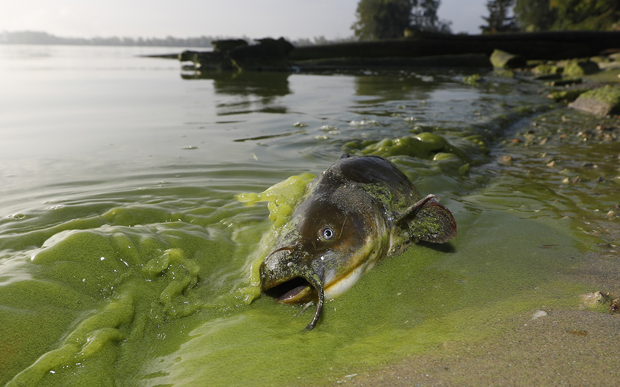

Algae-filled waters of North Toledo, Ohio, in September 2017 | Photo by Andy Morrison/The Blade via AP Photo

```r
### read data and create df for use
hab <- read.csv("hab_world.csv") #read csv with data
hab <- hab %>% filter(eventYear>1989) #remove first couple of year withs incomplete data
crs_use <- "+proj=laea +lat_0=30 +lon_0=-95" #create crs for shapefile data
hab_sub <- hab %>% drop_na(latitude) %>% drop_na(longitude) #remove data without sf data to map
hab_sf <- st_as_sf(x = hab_sub,
                   coords = c("latitude", "longitude"),
                   crs = crs_use) #turn hab dataframe into sf format

### create a sf dataframe of the world
world <- ne_countries(scale = "medium", returnclass = "sf")
```

### Methods and Results

To explore temporal trends in Harmful Algal Blooms data were visualized showing the location of algal blooms each year. Fig 1. shows the blooms which occurred that year in green. Fig 2. shows the total number of blooms which occurred from 1990 to 2021, with blooms being added to the figure each year. The map was created using the ggplot2 and sf packages, while the animation was done using gganimate and gifski.

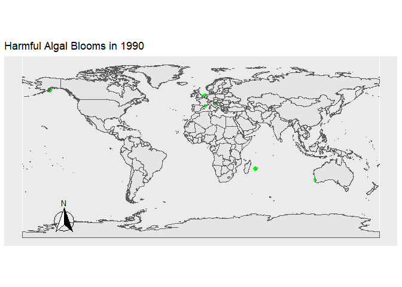

Figure 1. The location of all Harmful Algal Blooms in green observed each year.

```r
### create map of hab events overlayed on world map by year
map <- ggplot(data = hab_sub) + #define df
  geom_point(aes(x = longitude, y = latitude), color = "green", size = 2.5) +  #plot HAV events
  geom_sf(data = world) +  #plot world map
    annotation_north_arrow(location = "bl", which_north = "true",
        pad_x = unit(0.75, "in"), pad_y = unit(0.5, "cm"),
        style = north_arrow_fancy_orienteering) + #compass for aesthetics
        labs(title = "Harmful Algal Blooms in {frame_time}") + #title plot
        transition_time(eventYear) + #set the transition time for animation
        theme(axis.title.x=element_blank(),
          axis.text.x=element_blank(),
          axis.ticks.x=element_blank(),
          axis.title.y=element_blank(),
          axis.text.y=element_blank(),
          axis.ticks.y=element_blank()) + #remove x and y axis and give title
  ggtitle('Harmful Algal Blooms in {frame_time}')

#create year values
num_years <- max(hab_sub$eventYear) - min(hab_sub$eventYear) + 1

#create animation
animate(map, nframes = num_years, fps = 2, end_pause = TRUE)
```

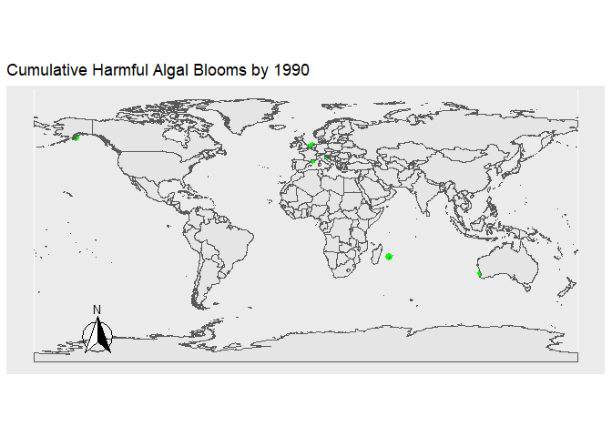

Figure 2. The location of all Harmful Algal Blooms in green plotted onto the map progressively by year.

```r
###create animation with cumulative data
map_with_shadow <- map +
  shadow_mark() +
  ggtitle('Cumulative Harmful Algal Blooms by {frame_time}')
animate(map_with_shadow, nframes = num_years, fps = 2, end_pause = TRUE)
```

After visualizing HAB events, their trend over time was explored. A least squared regression line showed that there was a strong relationship between time and the number of blooms (p=3.458e-05). However, the data had a clear non-linear aspect to it.

```r
# remove 2022 because its a year in progress which could skew data
hab_year <- hab %>% group_by(eventYear) %>%
  filter(eventYear != "2022") %>%
  count(eventYear) #count the number of blooms per year

lm_fit <- lm(n ~ eventYear, data=hab_year) #find linear fit
# summary(lm_fit)
```

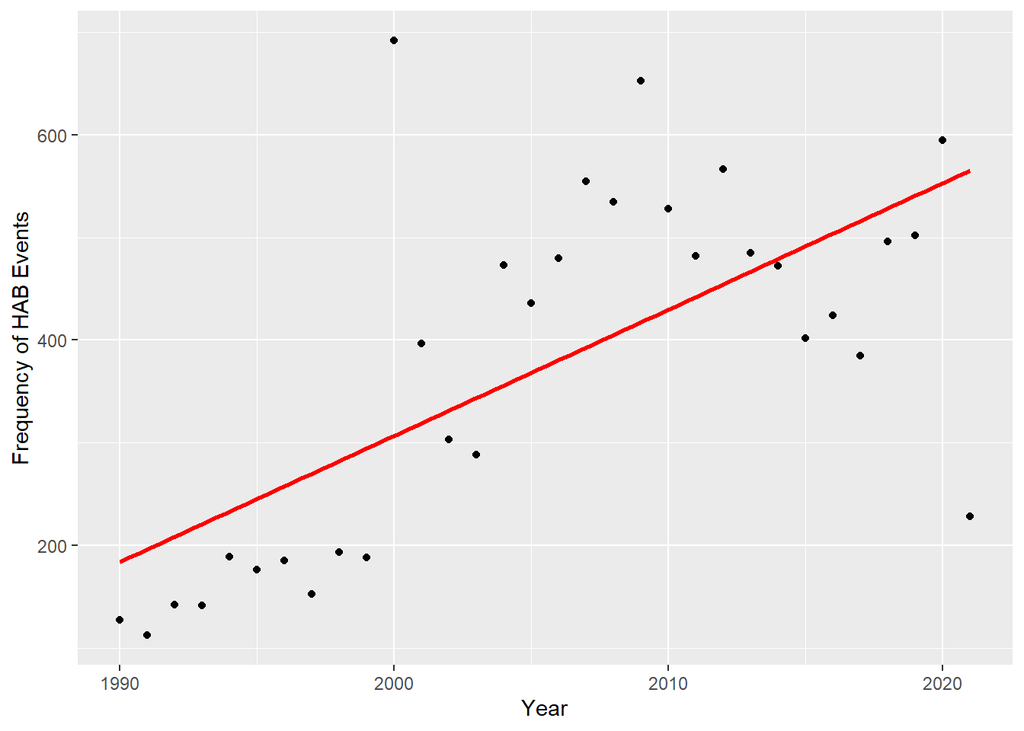

```r
# plot hab events per year and fit a linear regression line
ggplot(data=hab_year) +
  geom_point(aes(x=eventYear,y=n)) +
  geom_smooth(method='lm',aes(x=eventYear,y=n), se=FALSE,color='red') +
  labs( x = "Year", y = "Frequency of HAB Events")
```

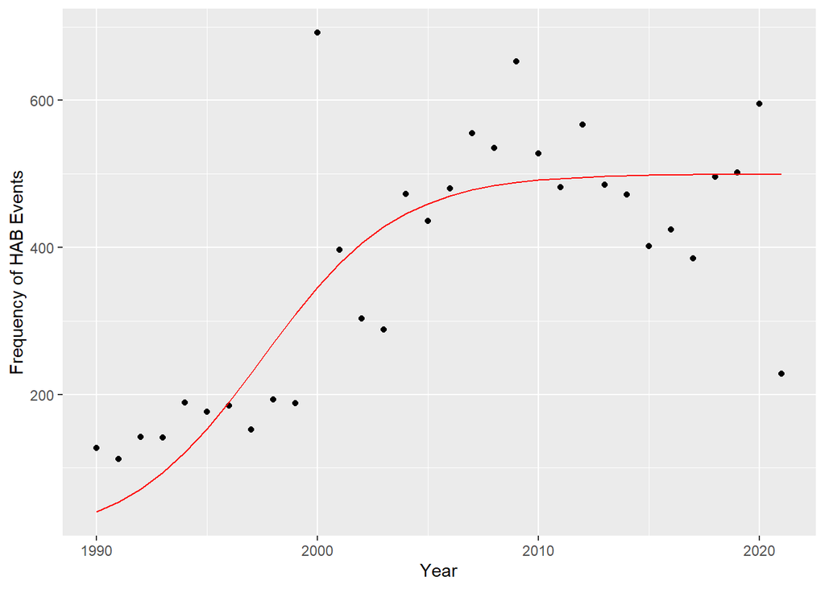

```r
#logistic growth function
logistic_growth <- function(t, N, p) {
  with (as.list(p), {
    dNdt <- rate*N*(1-N/K)
    return(list(dNdt))
  })
}

# definding time variables
T_init = 1990
T_lim = 2021
t = seq(T_init,T_lim,1)

# initial population
N_init <- c(N = 40)

#logistic parameters
estimatedRate <- 0.325
estimatedK <- 500

# parameters of the model
pars_logistic <- c (
  rate = estimatedRate, # rate at which the population changes
  K = estimatedK ) # limiting capacity

# solve ode and produce simulated data
N_t <- ode(y = N_init, times = t, parms = pars_logistic, func = logistic_growth)

# convert simulated data into tibble
df_sim_logistic <- as_tibble(N_t) %>%
  mutate(eventYear = as.numeric(time),
         N_logistic = as.numeric(N)) %>%
  select(-time,-N)

# join the data and the simulated data
year_log <- hab_year %>%
  left_join(df_sim_logistic, by = c("eventYear" = "eventYear"))

#graph
ggplot(data=year_log) +
  geom_point(aes(x=eventYear,y=n)) +
  geom_line(aes(x=eventYear,y=N_logistic), color='red') +
  labs( x = "Year", y = "Frequency of HAB Events")
```

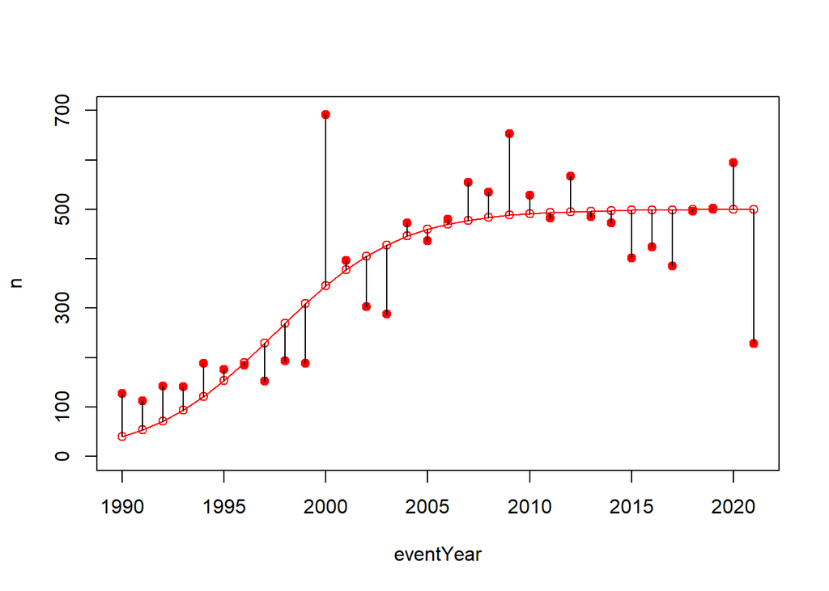

Figure 5. Simulated results based on the logistical model plotted against observed results in red. The difference was visualized by black lines.

```r
 #calculate sum of squares
# sum((df_sim_logistic$N_logistic - hab_year$n)^2)
# the observed prevalences:
with(hab_year, plot(eventYear, n, pch = 19, col = "red", ylim = c(0,700)))
# the model-predicted prevalences:
with(df_sim_logistic, lines(eventYear, N_logistic, col = "red", type = "o"))
# graph the model error by comparing observed and predicted prevalences
segments(hab_year$eventYear, hab_year$n, df_sim_logistic$eventYear, df_sim_logistic$N_logistic)
```

After showing the growth of blooms, how these events could be impacting the environment was explored. An issue of concern around blooms is their impact on fisheries, as blooms can poison important aquatic resources. Plotting the percentage of HAB events that are toxic to seafood shows that that percentage has been on the rise. Not only are the number of blooms increasing, but a greater percentage of them are damaging the fishing industry and causing health concerns for consumers of seafood.

```r
hab_seatox <- hab %>%
  select(eventYear, seafoodToxin) %>% #select variables of interest
  group_by(eventYear) %>%
  count(seafoodToxin) %>% #make variable n: number of toxic events/year
  pivot_wider(names_from = seafoodToxin, values_from = n) %>% #make 0 and 1 columns with n as the value
  rename("seatox_true" = "1","seatox_false"="0") %>% #rename columns
  mutate(seatox_true = replace_na(seatox_true, 0)) %>%
  mutate(seatox_total = seatox_true + seatox_false, seatox_percent = seatox_true/seatox_total) #create total event and percent true event columns

seatox_fit <- lm(seatox_percent ~ eventYear, data=hab_seatox) #find linear fit
# summary(seatox_fit) #find the goodness of the fit
```

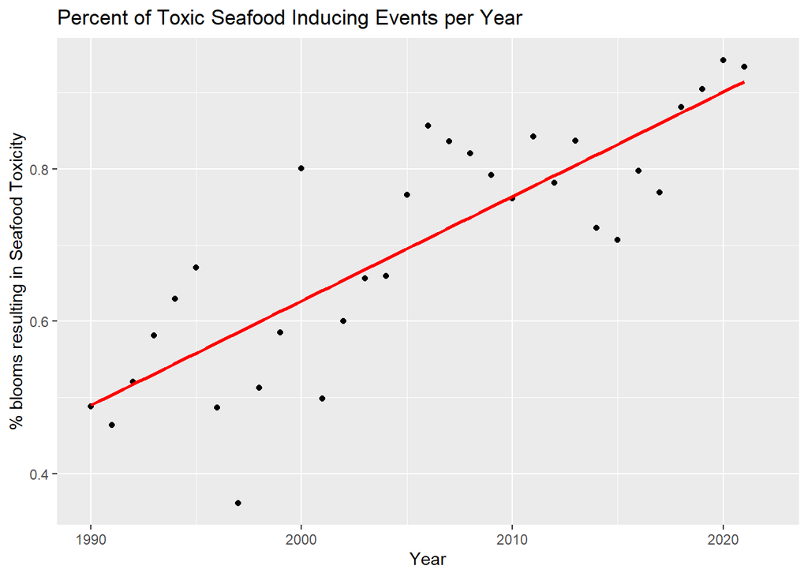

```r
# plot percent of blooms which are seafood toxic per year
ggplot(data = hab_seatox) +
  geom_point(aes(x=eventYear,y=seatox_percent)) +
  ggtitle("Percent of Toxic Seafood Inducing Events per Year") +
  geom_smooth(method='lm',aes(x=eventYear,y=seatox_percent), se=FALSE,color='red') +
  labs(x = "Year", y = "% blooms resulting in Seafood Toxicity")
```

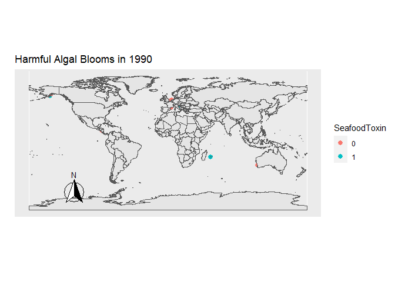

Figure 7. The location of all Harmful Algal Blooms observed each year. Blooms toxic for seafood are labeled blue. Blooms not toxic for seafood are labeled in orange.

```r
#change seatox presence into a categorical variable
hab_sub_seatox <- hab_sub %>%
  mutate(SeafoodToxin = as.character(seafoodToxin))

map2 <- ggplot(data = hab_sub_seatox) + #define df
  geom_point(aes(x = longitude, y = latitude, color = SeafoodToxin), size = 2.5) +  #plot HAB events
  geom_sf(data = world) +  #plot world map
    annotation_north_arrow(location = "bl", which_north = "true",
        pad_x = unit(0.75, "in"), pad_y = unit(0.5, "cm"),
        style = north_arrow_fancy_orienteering) + #compass for aesthetics
        labs(title = "Harmful Algal Blooms in {frame_time}") + #title plot
        transition_time(eventYear) + #set the transition time for animation
        labs(x = "",
             y = "") + #remove x and y axis and give title
  ggtitle('Harmful Algal Blooms in {frame_time}')
#animate map
animate(map2, nframes = num_years, fps = 2, end_pause = TRUE)
```

### Conclusions

Harmful Algal Blooms are showing a clear rise in frequency over the past decades. Understanding why this increase is occurring, what impacts it may have, and what future growth may look like will be important in the preservation of our marine resources. Not only are the number of blooms increasing, but due to their changing algal compositions, greater proportions of the blooms are damaging to marine life. These two clear trends show the urgency of the issue. blooms are estimated to cause around 20 million dollars in losses for US fisheries and around 50 million dollars in total damages when costs of public health and tourism are included (**WoodsHole.To?**) further understanding of global harmful bloom trends a next step for this project would be investigating explanatory factors of the trends observed in this report. Increasing concentrations of atmospheric and oceanic carbon dioxide, nutrient abundance from industrial processes, and increasing global temperatures have all been proposed as possible explanations (**Climate?**). Examining these trends and their correlations with blooms would help understand why blooms are occurring more frequently and becoming increasingly toxic.